# R Notebook on Health Data

Here we will install and load the required packages, tidyverse,dplyr,ggplot2

```r
install.packages("tidyverse")
```

```
Error in install.packages : Updating loaded packages
```

```r
library(tidyverse)
library(dplyr)
library(ggplot2)
```

Here we will read the csv file named as “Health_Data.csv”. Note that this file is in the same directory where the R system lies. So we do not need to mention the file path. Rather using the file name we can do it.

```r
health_df <- read.csv("Health_Data.csv")
```

The next few steps contains the step of understanding data. It includes how is the data, what are the type of each variable in the data, what are the summary statistics of the data. It also includes discovering the number of columns and number of rows in the data set.

View() function is used to view or preview the data in a separate tab

```r
View(health_df)
```

str() function is used to know the structure of each variable in the data set

```r
str(health_df)
```

```
'data.frame':   100 obs. of  10 variables:
 $ Patient_id          : int  202201001 202201002 202201003 202201004 202201005 202201006 202201007 202201008 202201009 202201010 ...
 $ Name                : chr  "Aniket" "Nayan" "Ritoprovo" "Swastika" ...
 $ Age                 : int  25 52 45 24 14 28 58 78 77 47 ...
 $ Gender              : chr  "Male" "Male" "Male" "Female" ...
 $ Disease             : chr  "Diabetics" "Thyroid" "Diabetics" "Thyroid" ...
 $ Duration._of_disease: int  1 2 3 4 5 4 2 3 1 5 ...
 $ Day_of_visit        : int  1 2 4 7 5 7 3 6 1 5 ...
 $ Family_history      : chr  "Yes" "No" "No" "No" ...
 $ Bill_amount         : int  12540 25123 4512 7845 2500 4512 500 879 4562 15145 ...
 $ Hospital_received   : num  7524 15074 2707 4707 1500 ...
```

summary() function is used to know the statistical summary of each numerical or continuous variable that are present in the data set. We may also use the glimpse() function in this case. Both of them will do the same work.

```r
summary(health_df)
```

```
   Patient_id            Name                Age           Gender            Disease
 Min.   :202201001   Length:100         Min.   :14.00   Length:100         Length:100
 1st Qu.:202201026   Class :character   1st Qu.:25.00   Class :character   Class :character
 Median :202201050   Mode  :character   Median :33.00   Mode  :character   Mode  :character
 Mean   :202201050                      Mean   :42.05
 3rd Qu.:202201075                      3rd Qu.:55.25
 Max.   :202201100                      Max.   :91.00
 Duration._of_disease  Day_of_visit  Family_history      Bill_amount    Hospital_received
 Min.   :0.00         Min.   :1.00   Length:100         Min.   :  100   Min.   :   60.0
 1st Qu.:1.00         1st Qu.:3.00   Class :character   1st Qu.: 1246   1st Qu.:  747.9
 Median :2.00         Median :4.50   Mode  :character   Median : 2658   Median : 1595.1
 Mean   :2.51         Mean   :4.25                      Mean   : 4809   Mean   : 2885.6
 3rd Qu.:4.00         3rd Qu.:6.00                      3rd Qu.: 7820   3rd Qu.: 4692.1
 Max.   :8.00         Max.   :7.00                      Max.   :25123   Max.   :15073.8
```

colnames() function is used to know the column names or variable names of the data set.

```r
colnames(health_df)
```

```
 [1] "Patient_id"           "Name"                 "Age"                  "Gender"
 [5] "Disease"              "Duration._of_disease" "Day_of_visit"         "Family_history"
 [9] "Bill_amount"          "Hospital_received"
```

nrow() function is used to know the number of observations available in the data set ncol() function is used to know the number of variables available in the data set.

```r
nrow(health_df)
ncol(health_df)
```

From here we start the data cleaning and manipulation works. For this we load the dplyr library and we use functions to create a column, filter values from column, select column, group them and summarize them with a piping operator.

mutate() function is used to create a new variable that carries some values tat we get from other present variables.

```r
health_01_df <- health_df %>% mutate(Doc_received=Bill_amount-Hospital_received)
head(health_01_df)
```

|  | Patient_id | Name | Age | Gender | Disease | Duration._of_disease | Day_of_visit | Family_history | Bill_amount | Hospital_received | Doc_received |
| --- | --- | --- | --- | --- | --- | --- | --- | --- | --- | --- | --- |
| 1 | 202201001 | Aniket | 25 | Male | Diabetics | 1 | 1 | Yes | 12540 | 7524.0 | 5016.0 |
| 2 | 202201002 | Nayan | 52 | Male | Thyroid | 2 | 2 | No | 25123 | 15073.8 | 10049.2 |
| 3 | 202201003 | Ritoprovo | 45 | Male | Diabetics | 3 | 4 | No | 4512 | 2707.2 | 1804.8 |
| 4 | 202201004 | Swastika | 24 | Female | Thyroid | 4 | 7 | No | 7845 | 4707.0 | 3138.0 |
| 5 | 202201005 | Aishi | 14 | Female | Thyroid | 5 | 5 | Yes | 2500 | 1500.0 | 1000.0 |
| 6 | 202201006 | Anindita | 28 | Female | Diabetics | 4 | 7 | Yes | 4512 | 2707.2 | 1804.8 |

```r
NA
```

mutate() with ifelse is used to create a variable that contians string values based on certain condition.

```r
health_02_df <- health_01_df %>% mutate(Feedback=ifelse(Bill_amount > mean(Bill_amount),'Bad','Good'))
head(health_02_df)
```

|  | Patient_id | Name | Age | Gender | Disease | Duration._of_disease | Day_of_visit | Family_history | Bill_amount | Hospital_received | Doc_received | Feedback |
| --- | --- | --- | --- | --- | --- | --- | --- | --- | --- | --- | --- | --- |
| 1 | 202201001 | Aniket | 25 | Male | Diabetics | 1 | 1 | Yes | 12540 | 7524.0 | 5016.0 | Bad |
| 2 | 202201002 | Nayan | 52 | Male | Thyroid | 2 | 2 | No | 25123 | 15073.8 | 10049.2 | Bad |
| 3 | 202201003 | Ritoprovo | 45 | Male | Diabetics | 3 | 4 | No | 4512 | 2707.2 | 1804.8 | Good |
| 4 | 202201004 | Swastika | 24 | Female | Thyroid | 4 | 7 | No | 7845 | 4707.0 | 3138.0 | Bad |
| 5 | 202201005 | Aishi | 14 | Female | Thyroid | 5 | 5 | Yes | 2500 | 1500.0 | 1000.0 | Good |
| 6 | 202201006 | Anindita | 28 | Female | Diabetics | 4 | 7 | Yes | 4512 | 2707.2 | 1804.8 | Good |

Using group_by() and count() we can calculate total occurrence of different values in a data set.

```r
health_02_df %>% group_by(Feedback) %>% count()
```

| Feedback | n |
| --- | --- |
| Bad | 33 |
| Good | 67 |

select() function is used to select different variables and help to perform data manipulation

```r
health_02_df %>% select(Age,Disease,Duration._of_disease)
```

| Age | Disease | Duration._of_disease |
| --- | --- | --- |
| 25 | Diabetics | 1 |
| 52 | Thyroid | 2 |
| 45 | Diabetics | 3 |
| 24 | Thyroid | 4 |
| 14 | Thyroid | 5 |
| 28 | Diabetics | 4 |
| 58 | Thyroid | 2 |
| 78 | Diabetics | 3 |
| 77 | Thyroid | 1 |
| 47 | Diabetics | 5 |

[output cut: 90 more lines]

rename() function is used to rename a variable into another variable. In other words rename function assigns new names to the same variable.

```r
health_final_df <- health_02_df %>% rename(Duration_of_disease = Duration._of_disease)
head(health_final_df)
```

|  | Patient_id | Name | Age | Gender | Disease | Duration_of_disease | Day_of_visit | Family_history | Bill_amount | Hospital_received | Doc_received | Feedback |
| --- | --- | --- | --- | --- | --- | --- | --- | --- | --- | --- | --- | --- |
| 1 | 202201001 | Aniket | 25 | Male | Diabetics | 1 | 1 | Yes | 12540 | 7524.0 | 5016.0 | Bad |
| 2 | 202201002 | Nayan | 52 | Male | Thyroid | 2 | 2 | No | 25123 | 15073.8 | 10049.2 | Bad |
| 3 | 202201003 | Ritoprovo | 45 | Male | Diabetics | 3 | 4 | No | 4512 | 2707.2 | 1804.8 | Good |
| 4 | 202201004 | Swastika | 24 | Female | Thyroid | 4 | 7 | No | 7845 | 4707.0 | 3138.0 | Bad |
| 5 | 202201005 | Aishi | 14 | Female | Thyroid | 5 | 5 | Yes | 2500 | 1500.0 | 1000.0 | Good |
| 6 | 202201006 | Anindita | 28 | Female | Diabetics | 4 | 7 | Yes | 4512 | 2707.2 | 1804.8 | Good |

```r
colnames(health_final_df)
```

```
 [1] "Patient_id"          "Name"                "Age"                 "Gender"
 [5] "Disease"             "Duration_of_disease" "Day_of_visit"        "Family_history"
 [9] "Bill_amount"         "Hospital_received"   "Doc_received"        "Feedback"
```

filter() is used to filter values that lies in observations depending on one or more condition.

```r
health_final_df %>% filter(Age < 30 & Duration_of_disease < 2)
```

| Patient_id | Name | Age | Gender | Disease | Duration_of_disease | Day_of_visit | Family_history | Bill_amount | Hospital_received | Doc_received | Feedback |
| --- | --- | --- | --- | --- | --- | --- | --- | --- | --- | --- | --- |
| 202201001 | Aniket | 25 | Male | Diabetics | 1 | 1 | Yes | 12540 | 7524.0 | 5016.0 | Bad |
| 202201035 | Kiyara | 28 | Female | Thyroid | 0 | 5 | Yes | 7803 | 4681.8 | 3121.2 | Bad |
| 202201037 | Poran | 20 | Male | Diabetics | 1 | 3 | No | 9865 | 5919.0 | 3946.0 | Bad |
| 202201046 | Iliana | 28 | Female | Thyroid | 0 | 7 | Yes | 1452 | 871.2 | 580.8 | Good |
| 202201057 | Dipti | 28 | Female | Diabetics | 1 | 5 | No | 14512 | 8707.2 | 5804.8 | Bad |
| 202201066 | Piyali | 23 | Female | Diabetics | 1 | 4 | No | 1235 | 741.0 | 494.0 | Good |
| 202201076 | Suvendu | 28 | Male | Diabetics | 0 | 6 | Yes | 4125 | 2475.0 | 1650.0 | Good |
| 202201080 | Monalisa | 21 | Female | Diabetics | 0 | 5 | Yes | 4589 | 2753.4 | 1835.6 | Good |
| 202201081 | Amit | 20 | Male | Diabetics | 0 | 6 | Yes | 7845 | 4707.0 | 3138.0 | Bad |
| 202201085 | Hrittika | 24 | Female | Diabetics | 0 | 5 | No | 6532 | 3919.2 | 2612.8 | Bad |

[output cut: 2 more lines]

we can also use filter() function to filter string values.

```r
health_final_df %>% filter(Disease == 'Diabetics' & Gender == 'Female')
```

| Patient_id | Name | Age | Gender | Disease | Duration_of_disease | Day_of_visit | Family_history | Bill_amount | Hospital_received | Doc_received | Feedback |
| --- | --- | --- | --- | --- | --- | --- | --- | --- | --- | --- | --- |
| 202201006 | Anindita | 28 | Female | Diabetics | 4 | 7 | Yes | 4512 | 2707.2 | 1804.8 | Good |
| 202201010 | Bidisha | 47 | Female | Diabetics | 5 | 5 | No | 15145 | 9087.0 | 6058.0 | Bad |
| 202201016 | Gargi | 25 | Female | Diabetics | 2 | 5 | Yes | 1500 | 900.0 | 600.0 | Good |
| 202201018 | Shreya | 49 | Female | Diabetics | 4 | 2 | No | 789 | 473.4 | 315.6 | Good |
| 202201022 | Anjali | 20 | Female | Diabetics | 2 | 4 | No | 999 | 599.4 | 399.6 | Good |
| 202201029 | Nandita | 29 | Female | Diabetics | 4 | 5 | Yes | 4200 | 2520.0 | 1680.0 | Good |
| 202201034 | Alia | 31 | Female | Diabetics | 0 | 3 | No | 7812 | 4687.2 | 3124.8 | Bad |
| 202201041 | Sinjini | 23 | Female | Diabetics | 4 | 5 | No | 4532 | 2719.2 | 1812.8 | Good |
| 202201053 | Trisha | 91 | Female | Diabetics | 4 | 5 | Yes | 1021 | 612.6 | 408.4 | Good |
| 202201057 | Dipti | 28 | Female | Diabetics | 1 | 5 | No | 14512 | 8707.2 | 5804.8 | Bad |

[output cut: 9 more lines]

group_by() function is used to make calculations of each parameter separately. summarize() is used to get Statistical and Mathematical values of variables.

```r
health_final_df %>% group_by(Gender) %>% summarize(avg_bill=mean(Bill_amount),min_bill=min(Bill_amount),max_bill=max(Bill_amount))
```

| Gender | avg_bill | min_bill | max_bill |
| --- | --- | --- | --- |
| Female | 5013.519 | 789 | 23154 |
| Male | 4588.000 | 100 | 25123 |

```r
health_final_df %>% group_by(Gender) %>% summarize(avg_hospital=mean(Hospital_received),min_hospital=min(Hospital_received),max_hospital=max(Hospital_received))
```

| Gender | avg_hospital | min_hospital | max_hospital |
| --- | --- | --- | --- |
| Female | 3008.112 | 473.4 | 13892.4 |
| Male | 2752.800 | 60.0 | 15073.8 |

```r
health_final_df%>%group_by(Gender)%>%summarize(avg_doc=mean(Doc_received),min_doc=min(Doc_received),max_doc=max(Doc_received))
```

| Gender | avg_doc | min_doc | max_doc |
| --- | --- | --- | --- |
| Female | 2005.408 | 315.6 | 9261.6 |
| Male | 1835.200 | 40.0 | 10049.2 |

ggplot() is the function used to plot graph of variables. Which plot object is to used depends upon what we are interested to do. geom_point() refers to the scatter plot and labs() refers to adding title,labels, subtitle etc.Facet_wrap() is used to separate the plot depending on the parameter used in the function.

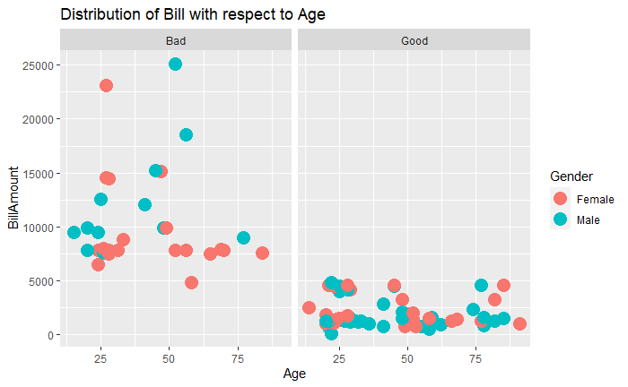

```r
p1=ggplot(data= health_final_df)+ geom_point(mapping=aes(x= Age,y=Bill_amount,color= Gender),size=5)+labs(title="Distribution of Bill with respect to Age",x="Age",y="BillAmount")+facet_wrap(~Feedback)
p1
```

```r
health_sp <- health_final_df %>% filter(Age<30 & Disease =='Diabetics') %>% select(Age,Disease)
View(health_sp)
```

Here we plot a bar chart. First we break the Age variable in some range, so that we can easily plot the bar graph. Here we see the frequency (count).

```r
age_range <- cut(health_sp$Age, breaks=c(0, 6, 12, 20, 25, 30))
age_range
```

```
 [1] (20,25] (25,30] (20,25] (20,25] (12,20] (25,30] (25,30] (12,20] (12,20] (20,25] (25,30] (12,20] (20,25]
[14] (20,25] (25,30] (20,25] (12,20] (20,25] (25,30] (20,25] (12,20]
Levels: (0,6] (6,12] (12,20] (20,25] (25,30]
```

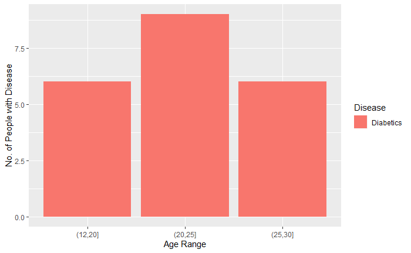

```r
p2=ggplot(data=health_sp)+geom_bar(mapping=aes(x=age_range,fill=Disease))+ labs(x="Age Range", y="No. of People with Disease")
p2
```

Here we count the total number of diseases separately. We treate them as values in the next plot

```r
health_final_df %>% group_by(Disease) %>% count()
```

| Disease | n |
| --- | --- |
| Diabetics | 39 |
| Pressure | 26 |
| Thyroid | 35 |

Here we plot a pie chart. We use the count as the values and labels them as the disease name. We use three different colors and labeling to understand the pie chart efficiently.

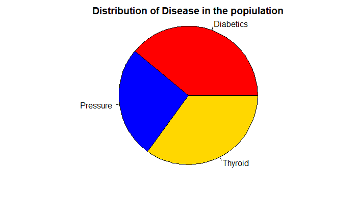

```r
values <- c(39,26,35)
labels <- c('Diabetics','Pressure','Thyroid')
radius <- 1
colors <- c('red','blue','gold')
main <- 'Distribution of Disease in the popiulation'
percentages <- round(values/sum(values)*100,2)
p3=pie(values,labels,radius=radius,main=main,col=colors)
```

```r
p3
```